# Pre_Assessment_03

## Recap

- National Data on SARS-CoV-2 Infections in Germany (Hamburg)
- 12 variables denoting
  - location
  - demographics
  - timestamps
  - ‘cardinalities’ (Amount of cases in a case-group)
  - status
- official open data set by the Federal Health Agency (RKI)

## Intermediate goal

[figure not shown]

## All the metrics!

- total cases
- total deaths
- total recoveries
- active cases
- 7-day average(s)
- daily (new) cases/average(s)
- metrics per sex
- metrics per age-bracket

## Other questions I want to answer

- What is the most popular day to get sick?
- What is the most popular day to tell your doctor?
- How likely are you to die from the CoViD?
- Who actually dies from the CoViD?
- Is there a functional relationship between infections and
  - population density and
  - age?
- What time was the worst and what was the best (since 2020)

## Data Prep

Just to be sure:

```r
library(tidyverse)
```

## Data Prep

Reading the data:

```r
inf_FRG <- read_csv("/home/jpv/Documents/Uni/D.Proc.Vis/rStudioWD/covid_frg_project/SARS-CoV-2_Infektionen_in_Deutschland/Aktuell_Deutschland_SarsCov2_Infektionen.csv")
```

## Data Prep

Translating variables:

```r
inf_FRG <- rename(inf_FRG, geo_ID = IdLandkreis)
inf_FRG <- rename(inf_FRG, age_group = Altersgruppe)
inf_FRG <- rename(inf_FRG, sex = Geschlecht)
inf_FRG <- rename(inf_FRG, rep_date = Meldedatum)
inf_FRG <- rename(inf_FRG, ref_date = Refdatum)
inf_FRG <- rename(inf_FRG, ref_rep_date = IstErkrankungsbeginn)
inf_FRG <- rename(inf_FRG, amount_case = AnzahlFall)
inf_FRG <- rename(inf_FRG, amount_death = AnzahlTodesfall)
inf_FRG <- rename(inf_FRG, amount_recovery = AnzahlGenesen)
inf_FRG <- rename(inf_FRG, new_case = NeuerFall)
inf_FRG <- rename(inf_FRG, new_death = NeuerTodesfall)
inf_FRG <- rename(inf_FRG, new_recovery = NeuGenesen)
```

## Data Prep

Changing some data types:

```r
inf_FRG$age_group <- as.factor(inf_FRG$age_group)
inf_FRG$sex <- as.factor(inf_FRG$sex)
inf_FRG$ref_rep_date <- as.logical(inf_FRG$ref_rep_date)
```

Filtering out Hamburg:

```r
inf_HH <- inf_FRG %>% filter(geo_ID == 2000)
```

## Data Prep

Glancing at the data:

```r
slice_sample(inf_HH, n = 7)
```

```
## # A tibble: 7 × 12
##   geo_ID age_group sex     rep_date   ref_date   ref_rep_date new_case new_death
##    <dbl> <fct>     <fct>   <date>     <date>     <lgl>           <dbl>     <dbl>
## 1   2000 A15-A34   M       2021-10-18 2021-10-12 TRUE                0        -9
## 2   2000 A80+      W       2021-03-25 2021-03-23 TRUE                0        -9
## 3   2000 A35-A59   unbeka… 2020-11-10 2020-11-10 FALSE               0        -9
## 4   2000 A80+      W       2021-11-26 2021-11-24 TRUE                0        -9
## 5   2000 A15-A34   W       2022-01-18 2022-01-01 TRUE                0        -9
## 6   2000 A15-A34   W       2022-02-27 2022-02-23 TRUE                0        -9
## 7   2000 A15-A34   M       2022-01-19 2021-12-30 TRUE                0        -9
## # … with 4 more variables: new_recovery <dbl>, amount_case <dbl>,
## #   amount_death <dbl>, amount_recovery <dbl>
```

## All the metrics! - part 2

### Total cases

```r
inf_HH %>% select(ref_date, amount_case) %>% arrange(ref_date) %>%
           mutate(cumulative_cases = cumsum(amount_case)) %>% slice_tail()
```

```
## # A tibble: 1 × 3
##   ref_date   amount_case cumulative_cases
##   <date>           <dbl>            <dbl>
## 1 2022-04-28           1           540782
```

## All the metrics! - part 2

### Total cases

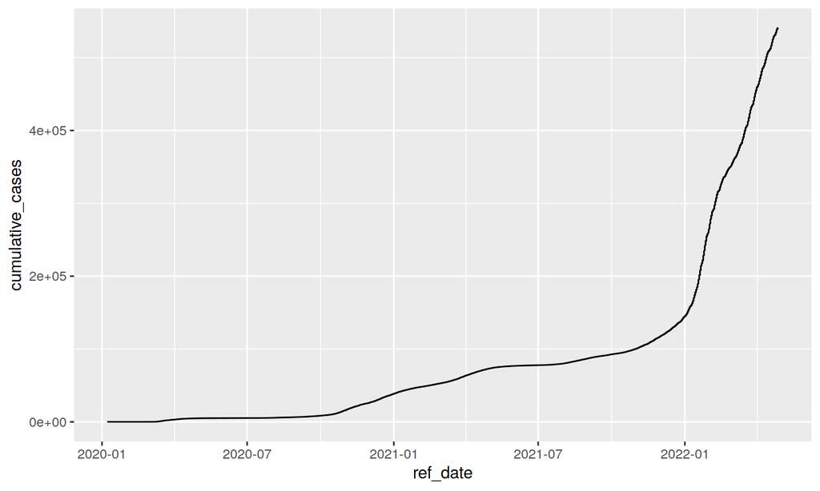

## All the metrics! - part 2

### Total deaths

```r
inf_HH %>% select(ref_date, amount_death) %>% arrange(ref_date) %>%
           mutate(cumulative_deaths = cumsum(amount_death)) %>% slice_tail()
```

```
## # A tibble: 1 × 3
##   ref_date   amount_death cumulative_deaths
##   <date>            <dbl>             <dbl>
## 1 2022-04-28            0              2524
```

## All the metrics! - part 2

### Total deaths

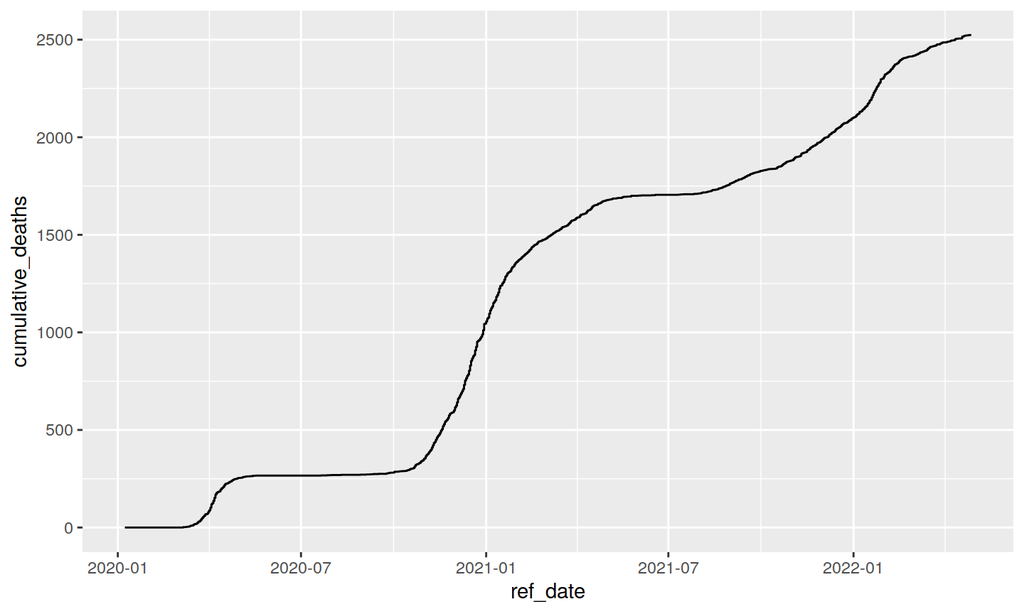

## All the metrics! - part 2

### Total recoveries

```r
inf_HH %>% select(ref_date, amount_recovery) %>% arrange(ref_date) %>%
           mutate(cumulative_recoveries = cumsum(amount_recovery)) %>%
           slice_tail()
```

```
## # A tibble: 1 × 3
##   ref_date   amount_recovery cumulative_recoveries
##   <date>               <dbl>                 <dbl>
## 1 2022-04-28               0                459644
```

## All the metrics! - part 2

### Total recoveries

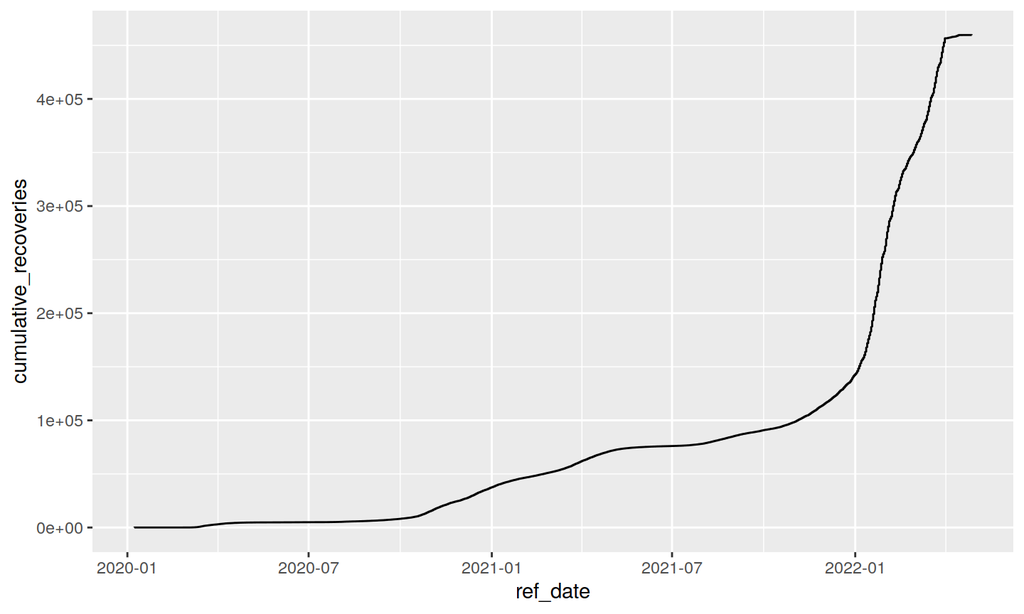

## All the metrics! - part 2

### Active cases

```r
inf_HH %>% summarise(active_cases = sum(amount_case - amount_death - amount_recovery))
```

```
## # A tibble: 1 × 1
##   active_cases
##          <dbl>
## 1        78614
```

## Issues

### rStudio

- RAM issue solved (<3 dplyr, largely)

### Data set

- internal logic/mechanics are pretty clear -> intuition largely verified (how it works)
- external logic not so much -> no intuition, and cannot verify (why it works like that)

### Thoughts2Code

- getting more and more acquainted with tidyverse (praised be dplyr!)
- can test more and more assumptions because I know how to translate thoughts2code

## Issues

### What questions to answer

- not a problem as such, but preparing the data to do so is an issue

### Key-Issues:

1. Thoughts2Code (getting better, though)
2. External Logic of the Data Set leads to biased assumptions
   - can’t find documentation that explains anything outside the actual mechanics

### Current Issue:

- I have to merge specific configurations of observations from 373 `.csv` files which also have to be pre-filtered